# hw02

Samuel Swain

2023-02-10

# Problem 1

### 1(a)

```
## MSE:
##  - Average: 1.947016
##  - SD 0.02844145
```

As we can see above, the average error is 1.9470162 per prediction with a standard deviation of 0.0284414. The predictive power of this model can definitely be improved or we can explore other models that will do a better job at predicting cost.

### 1(b)

```
##
## Call:
## lm(formula = cost ~ age + gend + intvn + drugs + ervis, data = df_1)
##
## Residuals:
##     Min      1Q  Median      3Q     Max
## -7.0979 -0.7699  0.1101  0.8554  3.3293
##
## Coefficients:
##              Estimate Std. Error t value Pr(>|t|)
## (Intercept)  6.290013   0.048606 129.408  < 2e-16 ***
## age          0.001477   0.048832   0.030  0.97587
## gend        -0.071141   0.048982  -1.452  0.14680
## intvn        1.283944   0.052426  24.491  < 2e-16 ***
## drugs       -0.088402   0.057351  -1.541  0.12362
## ervis        0.178760   0.060489   2.955  0.00322 **
## ---
## Signif. codes:  0 '***' 0.001 '**' 0.01 '*' 0.05 '.' 0.1 ' ' 1
##
## Residual standard error: 1.364 on 782 degrees of freedom
## Multiple R-squared:  0.491,  Adjusted R-squared:  0.4877
## F-statistic: 150.9 on 5 and 782 DF,  p-value: < 2.2e-16
```

Total number of interventions and number emergency room visits seem to have the highest effect on the cost of the subscriber. Increasing intvn by only one will increase the cost of the subscriber by about 812.08 whereas increasing ervis by just one will also increase the cost of the subscriber by about 376.53 dollars.

### 1(c)

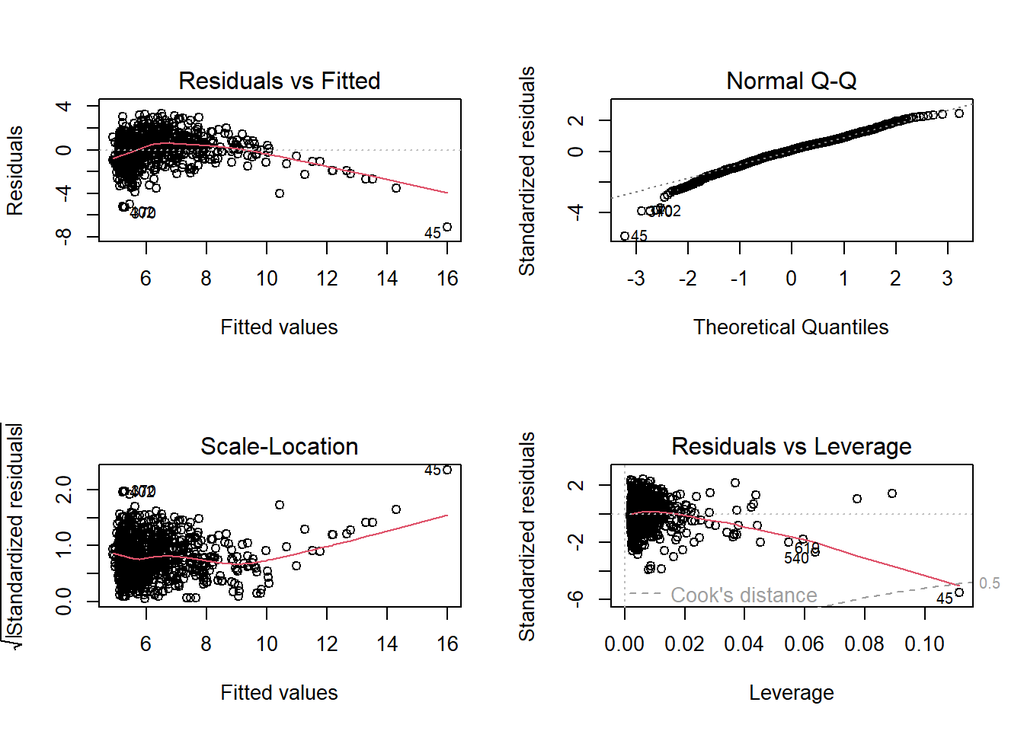

As we can see from the plots above, there are a lot of problems with using a linear model to attain the relationship between the features and the cost. The problems are listed below: - Non-linearity of the data based on the Residuals vs Fitted plot - A few outliers based on the Residuals vs Leverage plot